# Aside

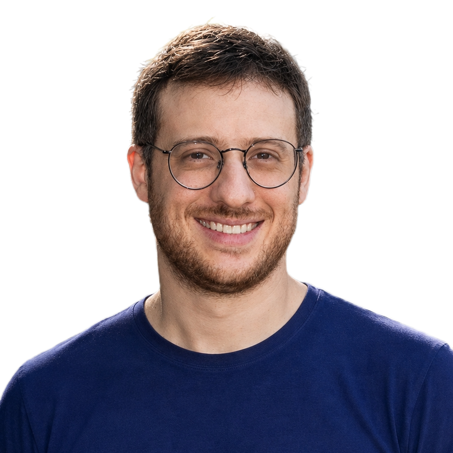

Download this CV

## Contact

São Paulo, SP, Brazil

[+55 11 95057-9817](https://wa.me/+5511950579817)

hi@danielvartan.com

danielvartan

danielvartan

0000-0001-7782-759X

## References

### [Vitor Kamada](https://www.linkedin.com/in/vitor-kamada)

BETC Havas  
Chief Media Officer (CMO)

### [Profa. Dra. Mariana Giannotti](https://orcid.org/0000-0002-7024-8015)

Center for Metropolitan Studies  
Polytechnic School  
University of São Paulo

### [Prof. Dr. Camilo R. Neto](https://orcid.org/0000-0001-6783-6695)

Graduate Program in Complex Systems Modeling  
School of Arts, Sciences and Humanities  
University of São Paulo

## Disclaimer

Developed with  
pagedown and datadrivencv  
[R](https://www.r-project.org) packages.

Source code available at:  
github.com/danielvartan/cv

Last updated on September 7, 2026.

# Main

## Daniel Vartanian

I’m a Media Manager at [Talent](https://talent.com.br/) Advertising Agency ([Publicis Groupe](https://www.publicisgroupe.com/)) and a Academic Collaborator at the University of São Paulo ([USP](https://www.usp.br/)). My work focuses on spatial analysis, [complex systems](https://en.wikipedia.org/wiki/Complex_system) modeling, and computational approaches to marketing, social, and public health challenges.

I develop open-source research software, primarily in [R](https://www.r-project.org/), [Python](https://www.python.org/), and [NetLogo](https://www.python.org/). My tools are used by researchers studying complex systems, [chronobiology](https://en.wikipedia.org/wiki/Chronobiology), food security, and climate change.

I’m also involved in building scientific communities and contributing to open-source science through [rOpenSci](https://ropensci.org/).

## Education

### MSc, Complex Systems Modeling

University of São Paulo ([USP](https://www.usp.br))

São Paulo, SP, Brazil

2025 - 2022

- Founded USP’s [Agent-Based Modeling Study Group](https://simbra.com.br).

### BSc, Marketing

University of São Paulo ([USP](https://www.usp.br))

São Paulo, SP, Brazil

2022 - 2016

## Work Experience

### Media Manager

[Talent Advertising Agency](https://talent.com.br/)

São Paulo, SP, Brazil

Present - 2026

- [Lead the creation](https://www.meioemensagem.com.br/comunicacao/talent-reformula-hub-de-ooh-que-passa-a-chamar-locus) of Talent’s [OOH](https://en.wikipedia.org/wiki/Outdoor_advertising) (out-of-home) media intelligence unit, developing data products that replace intuition-based decisions with a systematic approach to media planning.
- Develop geospatial analysis and models, including [Marketing Mix Models](https://en.wikipedia.org/wiki/Marketing_mix_modeling), classification, and optimization, to special projects such as fiber and broadband coverage mapping for [Claro](https://www.claro.com.br/), one of the largest telecom companies in Latin America.
- Build pipelines that turn client and OOH operator databases ([Eletromídia](https://www.eletromidia.com.br/), [JCDecaux](https://www.jcdecaux.com.br/), [Kallas](https://www.kallas.com.br/), [NEOOH](https://neooh.com.br/)) into a single source of truth for the whole planning process.
- Connect the agency with OOH tech and adtech vendors ([AllUnite](https://allunite.com/), [Taptap Digital](https://www.taptapdigital.com/), [bebot Digital](https://bebotdigital.com/), [Logan](https://logan.ai)) to evaluate integration and measurement capabilities for client campaigns.

### Research Fellow

[Center for Metropolitan Studies](https://centrodametropole.fflch.usp.br) ([USP](https://www.usp.br))

São Paulo, SP, Brazil

2026 - 2025

- Led geospatial modeling and large-scale data mining on the [FAPESP](https://fapesp.br)-funded [AcessoSAN](https://osf.io/ze6wt) project, investigating healthy food access in favelas and low-income urban communities across Brazil.
- Contributed to the development of the [GeoReDUS](https://www.redus.org.br/georedus) project, an open platform of Brazilian intra-municipal and regional data for public policy planning and monitoring.
- Built pipelines to process and analyze millions of records from [SISVAN](https://sisaps.saude.gov.br/sisvan), [Brazilian Revenue Service](https://www.gov.br/receitafederal), [DATASUS](https://datasus.saude.gov.br), [IBGE Census](https://www.ibge.gov.br/), and climate datasets like [WorldClim 2.1](https://www.worldclim.org) and [Mapbiomas](https://brasil.mapbiomas.org).
- Developed and delivered [trainning in R programming](https://danielvartan.com/r-course/) and other data related tools to approximately 20 researchers.

### Research Fellow

[Sustentarea](https://www.fsp.usp.br/sustentarea) ([FSP](https://www.fsp.usp.br)-[USP](https://www.usp.br))

São Paulo, SP, Brazil

2025 - 2024

- Led agent-based modeling on the [CNPq](https://www.gov.br/cnpq)-funded [Global Syndemic](https://doi.org/10.17605/OSF.IO/8W36C) project investigating climate change effects on child nutrition and health in Brazil.
- Developed [NetLogo](https://www.netlogo.org) models simulating food production systems and nutritional outcomes in children under 5, using climate projections from [Global Climate Models](https://www.worldclim.org/) and [IBGE](https://sidra.ibge.gov.br) data.
- Created the [logolink](https://danielvartan.github.io/logolink/) R package to provide analytical infrastructure for [NetLogo](https://www.netlogo.org) simulations.
- Produced [scientific papers](https://doi.org/10.21105/joss.08845), [pipelines](https://sustentarea.github.io/nutritional-status), and technical reports related to research in public health and climate science.
- Worked with interdisciplinary teams of nutritionists, biologists, statisticians, and health professionals across multiple universities as a member of the [RESICLIMA Network](https://resiclima.com.br/).

### Graduate Research Fellow

University of São Paulo ([USP](https://www.usp.br))

São Paulo, SP, Brazil

2024 - 2022

- Developed nested linear models investigating the relationship between human chronotype and latitude using Brazil’s largest chronotype dataset (n=115,166).
- Created the mctq R package (published on [CRAN](https://cran.r-project.org), peer-reviewed by [rOpenSci](https://ropensci.org)) for processing chronotype questionnaires.
- Built pipelines for statistical modeling and data processing.
- Completed [master’s thesis](https://doi.org/10.11606/D.100.2025.tde-02042025-063648) on chronotype and latitude relationships.

### Assistant Research Fellow

University of São Paulo ([USP](https://www.usp.br))

São Paulo, SP, Brazil

2022 - 2019

- Developed [actigraphy](https://en.wikipedia.org/wiki/Actigraphy) monitoring protocols and analytical models for circadian rhythm assessment using non-parametric methods, cosinor analysis, periodograms, and actogram visualizations.
- Created the actverse R package providing tools for [actigraphy](https://en.wikipedia.org/wiki/Actigraphy) data analysis.
- Co-authored the first [Brazilian Actigraphy Consensus](https://www.researchgate.net/publication/358348693_Consenso_Brasileiro_de_Actigrafia) and delivered training workshops to 60+ researchers, including a launch workshop at the 18th Brazilian Sleep Congress.
- Contributed to [USP](https://www.usp.br)’s Sleep Genetics project investigating associations between [chronotype](https://en.wikipedia.org/wiki/Chronotype) and [clock genes](https://en.wikipedia.org/wiki/Circadian_clock) using [actigraphy](https://en.wikipedia.org/wiki/Actigraphy) and genetic data from saliva samples across multi-centric cohorts in São Paulo and Baependi, Minas Gerais.
- Worked alongside interdisciplinary teams of doctors, biologists, psychologists, and health professionals across multiple research institutions.

### Undergraduate Research Fellow

University of São Paulo ([USP](https://www.usp.br))

São Paulo, SP, Brazil

2019 - 2016

- Provided statistical modeling and data analysis support for [circadian rhythm](https://en.wikipedia.org/wiki/Circadian_rhythm) and sleep research projects.
- Served as head of marketing and communications for [USP](https://www.usp.br)’s Interdisciplinary Sleep Research Group ([GIPSO](https://dgp.cnpq.br/dgp/espelhogrupo/0840395566366418)), securing media coverage in major Brazilian outlets like *Folha de São Paulo* and [TV Globo’s *Fantástico*](https://g1.globo.com/fantastico/noticia/2017/10/metade-da-populacao-se-sente-mal-no-horario-de-verao-revela-pesquisa.html).
- Co-developed sleep science courses through [EACH](https://each.usp.br)-[USP](https://www.usp.br)’s summer program and the [Coursera](https://www.coursera.org/learn/biologiadosono) platform.

## Affiliations

### [RESICLIMA Network](https://resiclima.com.br/)

Volunteer Academic Collaborator (2024-Present)

### [Sustentarea](https://www.fsp.usp.br/sustentarea/)

Volunteer Academic Collaborator (2024-Present)

### [rOpenSci](https://ropensci.org)

Software Developer  
(2021-Present)

### Interdisciplinary Sleep Research Group ([GIPSO](https://dgp.cnpq.br/dgp/espelhogrupo/0840395566366418))

Researcher (2016-2022)

## Languages

danielvartan

### English

Fluent

Fluent

Fluent

Fluent

### Portuguese

Native

Native

Native

Native

### Spanish

Intermediate

Proficient

Intermediate

Beginner

### French

Beginner

Beginner

Beginner

Beginner

## Selected Software Projects

### [PMTilesBR](https://pmtiles.com.br)

Creator and Maintainer

GitHub

2026

Geospatial tiled datasets for spatial visualization in Brazil.

### [LogoActions](https://github.com/danielvartan/logoactions)

Creator and Maintainer

GitHub

2026

[GitHub Actions](https://github.com/features/actions) for the [NetLogo](https://www.netlogo.org) framework.

### logolink

Creator and Maintainer

CRAN

2025

[R](https://www.r-project.org) package providing a [tidy](https://tidyverse.tidyverse.org/articles/manifesto.html) interface between [R](https://www.r-project.org) and [NetLogo](https://www.netlogo.org).

- Published on [CRAN](https://doi.org/10.32614/CRAN.package.logolink) (4K+ downloads).
- Currently under [peer review](https://github.com/ropensci/software-review/issues/741) by [rOpenSci](https://ropensci.org).

### [LogoScope](https://marketplace.visualstudio.com/items?itemName=danielvartan.logoscope)

Creator and Maintainer

Visual Studio Code Marketplace

2025

[VS Code](https://code.visualstudio.com) extension providing syntax highlighting for [NetLogo](https://www.netlogo.org).

- Published on [Visual Studio Code Marketplace](https://marketplace.visualstudio.com/items?itemName=danielvartan.logoscope) (780 downloads) and [Open VSX](https://open-vsx.org/extension/danielvartan/logoscope) (2.2K downloads).

### [LogoClim](https://github.com/sustentarea/logoclim)

Creator and Maintainer

CoMSES Net

2025

[NetLogo](https://www.netlogo.org) model developed to simulate and visualize climate conditions using data from [WorldClim 2.1](https://worldclim.org).

- Published on [CoMSES Net](https://www.comses.net/codebases/bccd451f-76a4-408a-85fd-c5024359ba9a).
- With an accompanying article published in [JOSS](https://doi.org/10.21105/joss.08845).

### brandr

Creator and Maintainer

CRAN

2024

[R](https://www.r-project.org) package for managing brand visual identity in data products using the [brand.yml](https://posit-dev.github.io/brand-yml) standard.

- Published on [CRAN](https://doi.org/10.32614/CRAN.package.brandr) (3K+ downloads).

### actverse

Creator and Maintainer

GitHub

2023

[R](https://www.r-project.org) package providing a [tidy](https://tidyverse.tidyverse.org/articles/manifesto.html) toolbox for [actigraphy](https://en.wikipedia.org/wiki/Actigraphy) data analysis.

### mctq

Creator and Maintainer

CRAN

2021

[R](https://www.r-project.org) package providing a [tidy](https://tidyverse.tidyverse.org/articles/manifesto.html) toolbox for processing the Munich ChronoType Questionnaire ([MCTQ](https://doi.org/10.1177/0748730402239679)).

- Published on [CRAN](https://doi.org/10.32614/CRAN.package.mctq) (15K+ downloads).
- [Peer reviewed](https://github.com/ropensci/software-review/issues/434) by [rOpenSci](https://ropensci.org).
- Cited in [chronobiology](https://en.wikipedia.org/wiki/Chronobiology) research across multiple countries.

## Programming Languages

danielvartan

### Expert

`R`

`NetLogo`

### Fluent

`Python`

`SQL`

### Intermediate

`Bash`

`C` `C++` `C#`

`GAML` ([GAMA](https://gama-platform.org/))

`JavaScript`

`Lua`

### Basic Proficiency

`GDScript` ([Godot](https://godotengine.org))

`Julia`

`Rust`

### Markup/Other Languages

`Git`

`Docker`

`HTML`

`CSS`

`SASS`

`Markdown`

`TeX` `LaTeX`

## Teaching Experience

### [An Introduction to the R Programming Language](https://danielvartan.github.io/r-course)

University of São Paulo

São Paulo, SP, Brazil

2026 - 2025

- Developed and delivered an introductory R programming course for researchers at the School of Public Health ([FSP](https://www.fsp.usp.br)) (2025) and School of Philosophy, Literature and Human Sciences ([FFLCH](https://www.fflch.usp.br)) (2026) at the University of São Paulo ([USP](https://www.usp.br)).
- Trained approximately 50 researchers across both institutions.

### [Technical High School Program in Administration](https://www.imprensaoficial.com.br/Certificacao/GatewayCertificaPDF.aspx?notarizacaoID=e3a88ea6-68b4-4957-94af-46b9368300c7)

São Paulo State Government

São Paulo, SP, Brazil

2024

- Taught mathematics to approximately 100 students across two public high schools in São Paulo State’s technical education program.

### [ACH0042 - Problem Based Learning II](https://uspdigital.usp.br/jupiterweb/obterDisciplina?nomdis=&sgldis=ACH0042)

University of São Paulo

São Paulo, SP, Brazil

2023

- Taught science and computational methods to 60 information systems students at [EACH](https://each.usp.br)-[USP](https://www.usp.br).

## Honors, Awards & Fellowships

### Technical Training (Level IV) Research Fellowship

São Paulo Research Foundation ([FAPESP](https://fapesp.br))

N/A

2026 - 2025

### Technological and Industrial Development (DTI-B) Research Fellowship

National Council for Scientific and Technological Development ([CNPq](https://www.gov.br/cnpq))

N/A

2025 - 2024

### Master’s Research Fellowship

Coordination for the Improvement of Higher Education Personnel ([CAPES](https://www.gov.br/capes))

N/A

2024 - 2022

## Selected Outreach Projects

### Interdisciplinary Brazilian Symposium on Agent-Based Models ([SIMBRA](https://simbra.com.br))

University of São Paulo

São Paulo, SP, Brazil

Present - 2026

Co-founded SIMBRA as an extension of USP’s Agent-Based Modeling Study Group (founder) to provide a national platform for researchers and students across disciplines to discuss and disseminate agent-based modeling approaches.

### [Durma na EACH](https://photos.app.goo.gl/spUsAgPNhdnEXQja8) (*Sleep at EACH*)

University of São Paulo

São Paulo, SP, Brazil

2018 - 2017

Created sleep and rest spaces for students at [EACH](https://each.usp.br)-[USP](https://www.usp.br) with plans for expansion to São Paulo public schools.

## Selected Publications

### [LogoClim: WorldClim in NetLogo](https://doi.org/10.21105/joss.08845)

Journal of Open Source Software

N/A

2026

Vartanian, D., Garcia, L., & Carvalho, A. M. (2026). LogoClim: WorldClim in NetLogo. *Journal of Open Source Software*, *11*(124), 8845. https://doi.org/10.21105/joss.08845

### [rOpenSci Packages: Development, Maintenance, and Peer Review](https://devguide.ropensci.org/pt/index.pt.html)

rOpenSci

N/A

2026

Equipe editorial da rOpenSci (2026). *Pacotes rOpenSci: Desenvolvimento, manutenção e revisão por pares* [rOpenSci packages: Development, maintenance, and peer review] (Portuguese translation: Pedro Faria, Francesca Palmeira, Beatriz Milz, Samuel Carleial Fernandes, Rafael Fontenelle, Ariana Moura Cabral, Ildeberto Vasconcelos, Daniel Vartanian, Marcelo Perlin, João Granja-Correia, António Pedro) Zenodo. https://zenodo.org/doi/10.5281/zenodo.18833361

### [Is Latitude Associated with Chronotype?](https://doi.org/10.11606/D.100.2025.tde-02042025-063648)

University of São Paulo

N/A

2025

Vartanian, D. (2025). *Is latitude associated with chronotype?* [Master’s thesis, University of São Paulo]. https://doi.org/10.11606/D.100.2025.tde-02042025-063648

### [Actigraphic Characterization of Sleep and Circadian Phenotypes of PER3 Gene VNTR Genotypes](https://doi.org/10.1080/07420528.2023.2256858)

Chronobiology International

N/A

2023

Viana-Mendes, J., Benedito-Silva, A. A., Andrade, M. A. M., Vartanian, D., Gonçalves, B. da S. B., Cipolla-Neto, J., & Pedrazzoli, M. (2023). Actigraphic characterization of sleep and circadian phenotypes of PER3 gene VNTR genotypes. *Chronobiology International*, *40*(9), 1244–1250. https://doi.org/10.1080/07420528.2023.2256858

### [Brazilian Actigraphy Consensus](https://www.researchgate.net/publication/358348693_Consenso_Brasileiro_de_Actigrafia)

Segmento Farma Editores

N/A

2021

Pedrazzoli, M., & Gonçalves, B. S. B. (Eds.) (with Benedito-Silva, A. A., Toscanini, A. C., Souza, A. P. P. B., Conway, B. A., Vartanian, D., Santos, E. H. R., Pires, M. L. N., & Leocadio-Miguel, M. A.). (2021). *Consenso brasileiro de actigrafia* [Brazilian actigraphy consensus]. Segmento Farma Editores. ISBN 978-65-992059-6-5.

### [Early Chronotype with Advanced Activity Rhythms and Dim Light Melatonin Onset in a Rural Population](https://doi.org/10.1111/jpi.12675)

Journal of Pineal Research

N/A

2020

Ruiz, F. S., Beijamini, F., Beale, A. D., Gonçalves, B. D. S. B., Vartanian, D., Taporoski, T. P., Middleton, B., Krieger, J. E., Vallada, H., Arendt, J., Pereira, A. C., Knutson, K. L., Pedrazzoli, M., & Von Schantz, M. (2020). Early chronotype with advanced activity rhythms and dim light melatonin onset in a rural population. *Journal of Pineal Research*, *69*(3). https://doi.org/10.1111/jpi.12675